# Escuela Nacional de Inteligencia

## Curso de Estadística para el Análisis Social

### Prof. José Manuel Magallanes, PhD

## **Exploración de Datos**

La exploración de datos tiene en cuenta:

- El tipo de escala en que estén los datos (dicotómica, politómica, etc.); y las combinaciones entre estas.
- La detección del comportamiento de los datos y su afinidad (o no) con algun modelo teórico.

Los contenidos para esta sesión se organizan asi:

1. **AED Univariado**
- Categóricos
  - Dicotómicos
  - Politómicos
    - No-Ordinal
    - Ordinal
- Numéricos
  - Conteos
  - Mediciones (ratio o intervalo)
2. **AED Bivariado**
- Categorico - Categorico
- Categorico - Numérico
- Numérico - Numérico

## Exploración de variables categoricas No Ordinales

Carguemos la data:

```r
folder='data'
fileName='idePeru2012.csv'
fileToRead=file.path(folder,fileName)
myData=read.csv(fileToRead,strip.white = T,stringsAsFactors = F)
```

Veámos cuáles son las categóricas:

```r
str(myData)
```

```
## 'data.frame':    195 obs. of  14 variables:
##  $ ubiProv        : int  10100 10200 10300 10400 10500 10600 10700 20100 20200 20300 ...
##  $ ubiReg         : int  10000 10000 10000 10000 10000 10000 10000 20000 20000 20000 ...
##  $ DEPARTAMENTO   : chr  "AMAZONAS" "AMAZONAS" "AMAZONAS" "AMAZONAS" ...
##  $ PROVINCIA      : chr  "Chachapoyas" "Bagua" "Bongara" "Condorcanqui" ...
##  $ IDE            : num  0.774 0.662 0.632 0.46 0.605 ...
##  $ IDENTIDAD      : num  98.6 94.6 97.5 86.2 96.2 ...
##  $ SALUD          : num  25.45 14.61 9.01 8.56 12.42 ...
##  $ EDUCACION      : num  91.5 79.8 76.4 52.2 74.7 ...
##  $ SANEAMIENTO    : num  70.3 64.5 54.8 37.7 43.3 ...
##  $ ELECTRIFICACION: num  84 67.9 72.2 39.5 67.4 ...
##  $ POBLACION      : int  54783 77438 32317 51802 52185 30236 118747 161003 7974 16879 ...
##  $ COSTA          : chr  "NO" "NO" "NO" "NO" ...
##  $ CAPITAL        : chr  "SI" "NO" "NO" "NO" ...
##  $ TAMANO         : int  2 2 1 2 2 1 3 3 1 1 ...
```

Veamos COSTA:

```r
table(myData$COSTA)
```

```
##
##  NO  SI
## 168  27
```

Con esta tabla de frecuencias, vemos que hay 27 provincias que están en la costa.

Grafiquemos nuestra variable COSTA:

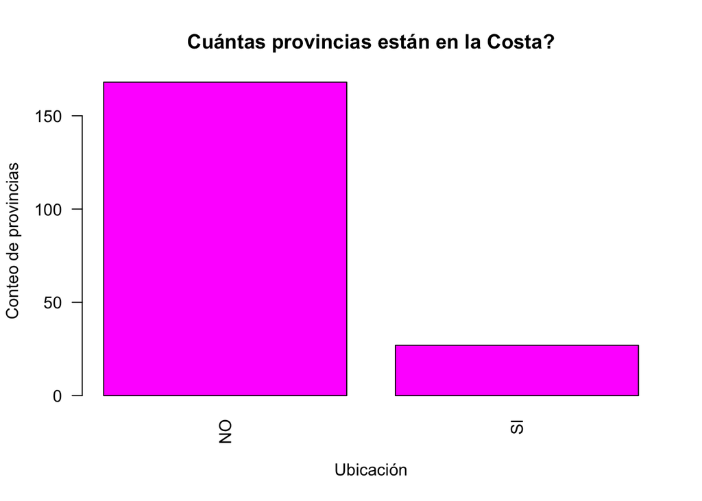

```r
#Data
toPlot=table(myData$COSTA) # se plotea la tabla de frequencias

#Argumentos
tituloPlot='Cuántas provincias están en la Costa?'
tituloX='Ubicación'
tituloY='Conteo de provincias'

# a plotear:
barplot(toPlot,col='magenta',
        xlab=tituloX,
        ylab=tituloY,
        main= tituloPlot,
        las=2)
```

El **promedio** que podemos calcular aqui es la moda, el valor que más se repite:

```r
# la moda se calcula a partir de la tabla de frecuencias
frecuencias=table(myData$COSTA)
names(frecuencias[which.max(frecuencias)])
```

```
## [1] "NO"
```

Las nominales tienes dispersión, que justamente interpreta si la moda es representativa o no. Usamos para ellos la formula de Herfindahl, si el resultado se acerca más a ‘1’, la variable tiene moda predominante, si se acerca a ‘0’, la moda no es relevante:

```r
#variable a analizar
distribucion=table(myData$COSTA)

# aplicando
H=sum(prop.table(distribucion)^2)
#normalizando
(H-(1/length(distribucion)))/(1-(1/length(distribucion)))
```

```
## [1] 0.5228402
```

## Exploración de variables categoricas Ordinales

No tenemos una variable ordinal, pero creemos una usando el propio IDE. Dividamos ese indicador en cinco grupos:

```r
gruposCantidad=5
etiquetas=c('muy bajo','bajo','medio','alto','muy alto')
myData$ideOrdinal=cut(myData$IDE,
                      breaks = gruposCantidad,
                      labels = etiquetas,
                      ordered_result = T) # resultado será ordinal
```

Acabamos de ‘cortar’ el IDE en cinco grupos. Veamos qué tenemos en la data:

```r
str(myData)
```

```
## 'data.frame':    195 obs. of  15 variables:
##  $ ubiProv        : int  10100 10200 10300 10400 10500 10600 10700 20100 20200 20300 ...
##  $ ubiReg         : int  10000 10000 10000 10000 10000 10000 10000 20000 20000 20000 ...
##  $ DEPARTAMENTO   : chr  "AMAZONAS" "AMAZONAS" "AMAZONAS" "AMAZONAS" ...
##  $ PROVINCIA      : chr  "Chachapoyas" "Bagua" "Bongara" "Condorcanqui" ...
##  $ IDE            : num  0.774 0.662 0.632 0.46 0.605 ...
##  $ IDENTIDAD      : num  98.6 94.6 97.5 86.2 96.2 ...
##  $ SALUD          : num  25.45 14.61 9.01 8.56 12.42 ...
##  $ EDUCACION      : num  91.5 79.8 76.4 52.2 74.7 ...
##  $ SANEAMIENTO    : num  70.3 64.5 54.8 37.7 43.3 ...
##  $ ELECTRIFICACION: num  84 67.9 72.2 39.5 67.4 ...
##  $ POBLACION      : int  54783 77438 32317 51802 52185 30236 118747 161003 7974 16879 ...
##  $ COSTA          : chr  "NO" "NO" "NO" "NO" ...
##  $ CAPITAL        : chr  "SI" "NO" "NO" "NO" ...
##  $ TAMANO         : int  2 2 1 2 2 1 3 3 1 1 ...
##  $ ideOrdinal     : Ord.factor w/ 5 levels "muy bajo"<"bajo"<..: 4 3 3 1 2 3 2 4 3 2 ...
```

Cómo se distribuye?

```r
table(myData$ideOrdinal)
```

```
##
## muy bajo     bajo    medio     alto muy alto
##       15       68       63       34       15
```

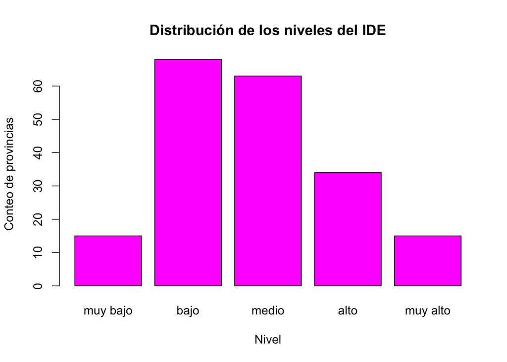

```r
toPlot=table(myData$ideOrdinal)
barplot(toPlot,col='magenta',
        xlab='Nivel',
        ylab='Conteo de provincias',
        main='Distribución de los niveles del IDE')
```

La moda la podemos calcula nuevamente:

```r
# la moda se calcula a partir de la tabla de frecuencias
frecuencias=table(myData$ideOrdinal)
names(frecuencias[which.max(frecuencias)])
```

```
## [1] "bajo"
```

Podemos calcular otro **promedio**, la mediana:

```r
median(as.numeric(myData$ideOrdinal),na.rm = T)
```

```
## [1] 3
```

La mediana se interpreta aquí como:‘la *mitad* de las provincias llega hasta nivel IDE-medio’. Confirmemos:

```r
cumsum(prop.table(table(myData$ideOrdinal)))
```

```
##   muy bajo       bajo      medio       alto   muy alto
## 0.07692308 0.42564103 0.74871795 0.92307692 1.00000000
```

Desde las ordinales podemos pedir los boxplots:

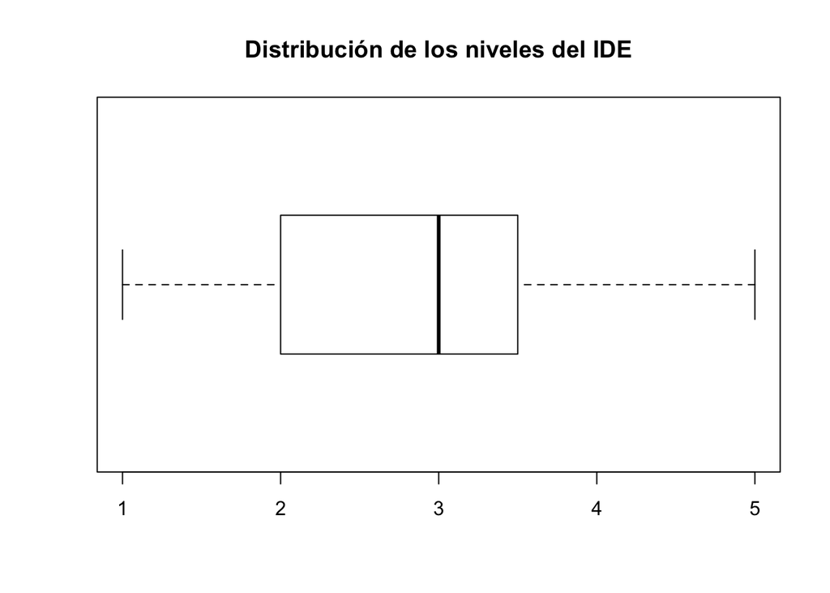

```r
boxplot(myData$ideOrdinal,
        horizontal = T,
        main='Distribución de los niveles del IDE')
```

El ancho de la caja central sugiere una idea de dispersion, mientras más ancha la caja central, más dspersión hay; mientras más alejadas las ‘patitas centrales’ eleva la posibilidad de *outliers*.

Hablando de dispersión, Finalmente, veamos la dispersion usando Herfindahl:

```r
#variable a analizar
distribucion=table(myData$ideOrdinal)

# aplicando
H=sum(prop.table(distribucion)^2)
#normalizando
(H-(1/length(distribucion)))/(1-(1/length(distribucion)))
```

```
## [1] 0.08527285
```

Otra medida de interés, relacionada a lo que se ve en el boxplot, es el rango intercuartil (al ancho de la caja):

```r
IQR(myData$ideOrdinal)
```

```
## [1] 1.5
```

Finalmente, puedes calcular la **desviación absoluta de la mediana**:

```r
mad(as.numeric(myData$ideOrdinal))
```

```
## [1] 1.4826
```

Estos dos ultimos estadísticos sirven esencialmente para comparar, sin descartar que uno pueda establecer valores meta para ellos.

Inicio

## Explorando conteos

La variable *población* puede servir para ello:

```r
myData$POBLACION
```

```
##   [1]   54783   77438   32317   51802   52185   30236  118747  161003
##   [9]    7974   16879    9013   32452   46434   21920   46032    8340
##  [17]   63726   29972   56102   23888   10283   30536   29196   19509
##  [25]  427157   31006   57969  105694  163662   13399   32722   51667
##  [33]   57750   26987  936464   57187   39317   38990   86542   18540
##  [41]   53047   15164  261382   34298   10472  102619   87160   67167
##  [49]   32023   11028   12255   24213   23412  368639   80086   95433
##  [57]  167670   32602  143667  100009  198354  145478   54622   57492
##  [65]   23885   45955  969170  427580   28318   57262   72583   39973
##  [73]  102826   81878   68390  179515   31521   50323   88967   63039
##  [81]  153773   73243   60816   19500   45172   23361  107715  301396
##  [89]   57957   52025   22403   73621  129953   30594   69003   32060
##  [97]   38257   33715  349036  210098   58817   12621  132986  497299
## [105]   58942  193140   88524   27722  244727  111631   45858   53564
## [113]  914036  120884   16910   84037   32400   92237  101954   85687
## [121]  149616   61329   31402  101167  836299  104820  288141 8481415
## [129]  143216    8139   14669  222877  182409   79177  213188   22217
## [137]   27842  550031  117163   69508   67143   72706   70782   59620
## [145]   91988   22906   12745   78890   27275   68694  156259   51789
## [153]   89543  734437  141708  127423  159486  122725  309605  133148
## [161]   71075  244692  139092   87812  142711   84865   67726   51039
## [169]   77355   26799   62247  276352   68253   48179  136414   55815
## [177]   38152   25357   83825   51489   42369  120387  179184   73460
## [185]  302852    8435    9641    7987  159548   19180   49499  366040
## [193]   50569   56756    4251
```

Si se tienen pocos valores, podriamos graficar un gráfico de barras, pero como ese no es el caso, corresponde hacer un histograma:

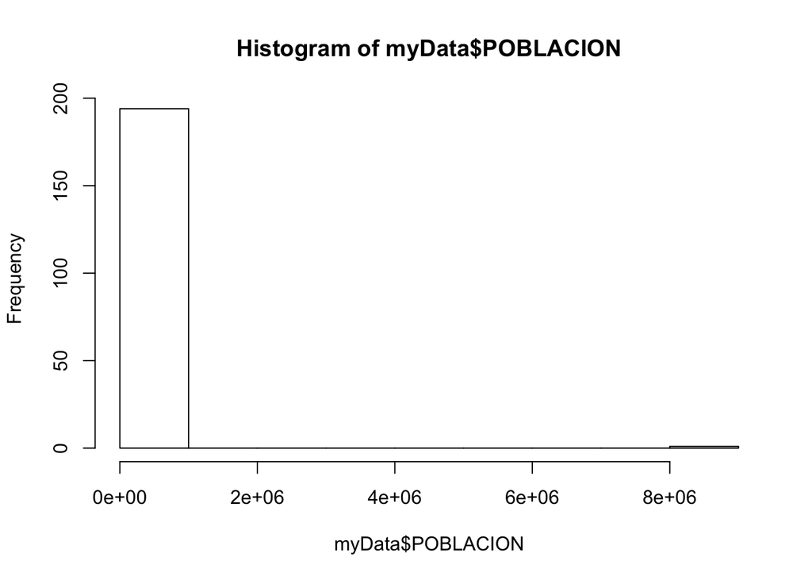

```r
hist(myData$POBLACION, breaks = "Sturges") # cambiar breaks a 30?
```

Veamos sus estadísticos:

```r
summary(myData$POBLACION)
```

```
##    Min. 1st Qu.  Median    Mean 3rd Qu.    Max.
##    4251   32188   63039  154543  121804 8481415
```

Un boxplot:

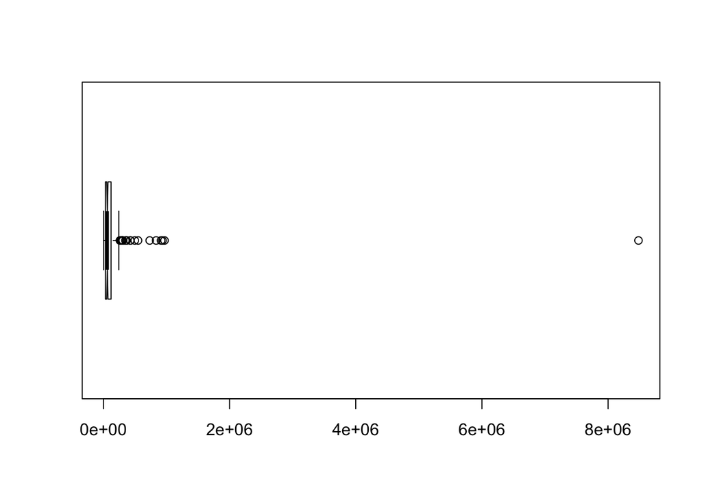

```r
detectorAtipicos=1.5
boxplot(myData$POBLACION,
        horizontal = T,
        range=detectorAtipicos,
        notch = T)
```

El siguiente comando entrega los valores numéricos que se usaron para construir el boxplot:

```r
boxplot.stats(myData$POBLACION, coef = detectorAtipicos)
```

```
## $stats
## [1]   4251.0  32188.5  63039.0 121804.5 244727.0
##
## $n
## [1] 195
##
## $conf
## [1] 52899.29 73178.71
##
## $out
##  [1]  427157  936464  261382  368639  969170  427580  301396  349036
##  [9]  497299  914036  836299  288141 8481415  550031  734437  309605
## [17]  276352  302852  366040
```

De los resultados anteriores, podemos saber que provincias son las atipicas:

```r
resultados=boxplot.stats(myData$POBLACION, coef = 1.5)
resultados$stats[5]
```

```
## [1] 244727
```

Ese es el máximo valor admitido (con coef=1.5). Pidamos que provincias tienen una población mayor:

```r
tope=resultados$stats[5]
myData[myData$POBLACION>tope,]$PROVINCIA
```

```
##  [1] "Santa"            "Arequipa"         "Huamanga"
##  [4] "Cajamarca"        "Callao"           "Cusco"
##  [7] "Huanuco"          "Ica"              "Huancayo"
## [10] "Trujillo"         "Chiclayo"         "Lambayeque"
## [13] "Lima"             "Maynas"           "Piura"
## [16] "Sullana"          "San Roman"        "Tacna"
## [19] "Coronel Portillo"
```

De lo anterior podemos saber cuantos atípicos son provincias con ciudad capital:

```r
table(myData[myData$POBLACION>tope,]$CAPITAL)
```

```
##
## NO SI
##  4 15
```

Si aumentásemos el valor de *coef* pediríamos atipicos mucho más extremos.

Inicio

## Explorando mediciones

Las mediciones dan valores continuos (aceptan decimales). Utilicemos el propio IDE:

```r
summary(myData$IDE)
```

```
##    Min. 1st Qu.  Median    Mean 3rd Qu.    Max.
##  0.4245  0.5806  0.6367  0.6519  0.7164  0.9104
```

Los estadísticos no muestran la desviación típica, aquí está:

```r
sd(myData$IDE)
```

```
## [1] 0.1010597
```

Pidamos un histograma:

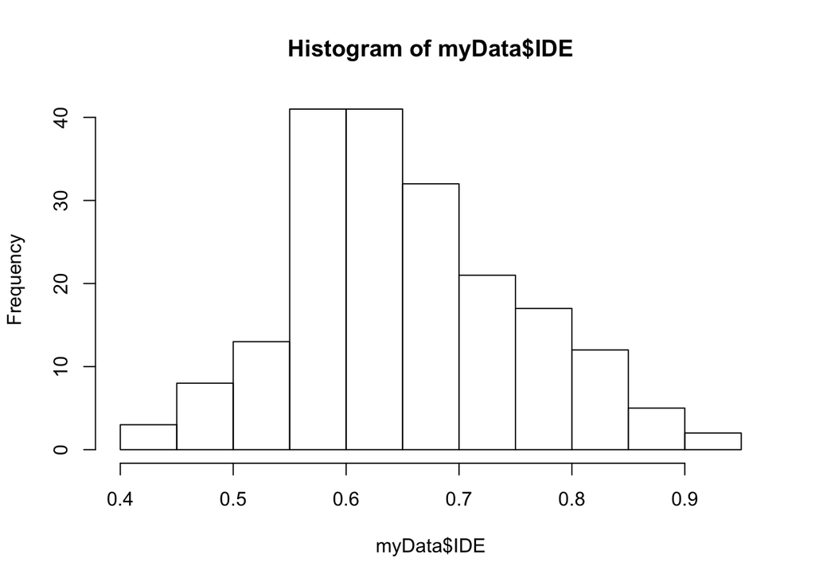

```r
hist(myData$IDE)
```

Las mediciones nos sugieren comportamiento normal, veamos:

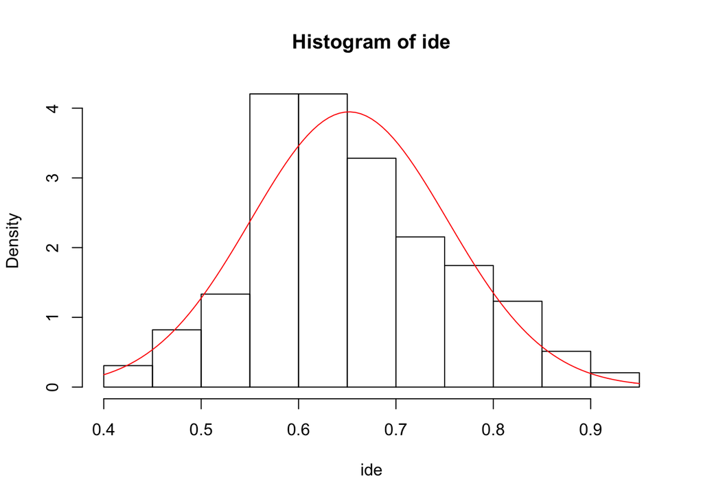

```r
ide <- myData$IDE
hist(ide, freq = F)
curve(dnorm(x, mean=mean(ide), sd=sd(ide)), add=TRUE,col='red')
```

…Y nuestro boxplot:

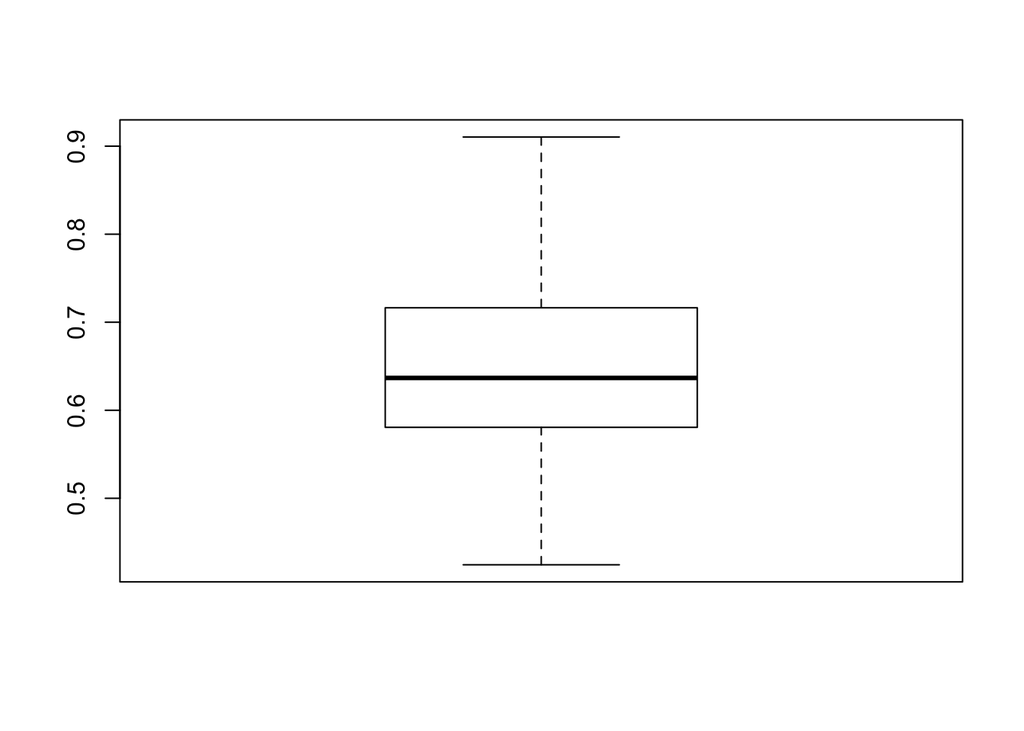

```r
boxplot(myData$IDE)
```

Los gráficos anteriores no sólo sugieren poca dispersión, sino simetría. Veamos:

```r
library(moments)
skewness(myData$IDE)  #0.3513978
```

```
## [1] 0.3513978
```

Y como seria la kurtosis (que no se detecta en el boxplot, pero sí se sugiere en el histograma):

```r
kurtosis(myData$IDE) #2.738378
```

```
## [1] 2.738378
```

Inicio

## Categórico - Categórico

Veamos como se distribuye *CAPITAL*:

```r
table(myData$CAPITAL)
```

```
##
##  NO  SI
## 170  25
```

… y *COSTA*:

```r
table(myData$COSTA)
```

```
##
##  NO  SI
## 168  27
```

La manera simple de analizar relaciones *cat-cat* (asociación) es la **tabla de contingencia** (crosstab):

```r
table(myData$COSTA,myData$CAPITAL)
```

```
##
##       NO  SI
##   NO 149  19
##   SI  21   6
```

Alternativamente;

```r
prop.table(table(myData$COSTA,myData$CAPITAL),margin = 2) #columna
```

```
##
##             NO        SI
##   NO 0.8764706 0.7600000
##   SI 0.1235294 0.2400000
```

La relación detectada se refleja en el gráfico:

[figure not shown]

```r
legendPlot=levels(as.factor(myData$CAPITAL))
bartable = table(myData$CAPITAL,myData$COSTA)  ## get the cross tab
barplot(bartable, beside = TRUE,
        legend.text = c('Si','No'),
        args.legend = list(title='Es Capital?'))  ## plot
```

## Categórico - Numérico

Lo usual es ver como se comporta una variable numérica ante diversos factores. Veamos estadísticos:

```r
aggregate(IDE ~ CAPITAL, data=myData,FUN=mean)
```

```
##   CAPITAL       IDE
## 1      NO 0.6321624
## 2      SI 0.7862920
```

```r
aggregate(cbind(SALUD, EDUCACION,ELECTRIFICACION) ~ CAPITAL,
          data=myData,
          FUN=mean)
```

```
##   CAPITAL    SALUD EDUCACION ELECTRIFICACION
## 1      NO 10.31820  79.07867        69.48203
## 2      SI 22.80164  89.55430        89.99860
```

```r
aggregate(cbind(SALUD, EDUCACION,ELECTRIFICACION) ~ CAPITAL + COSTA,
          data=myData,
          FUN=mean)
```

```
##   CAPITAL COSTA     SALUD EDUCACION ELECTRIFICACION
## 1      NO    NO  9.390129  77.66661        66.93058
## 2      SI    NO 19.949032  89.07037        88.54971
## 3      NO    SI 16.903048  89.09752        87.58516
## 4      SI    SI 31.834900  91.08673        94.58677
```

Podemos graficar:

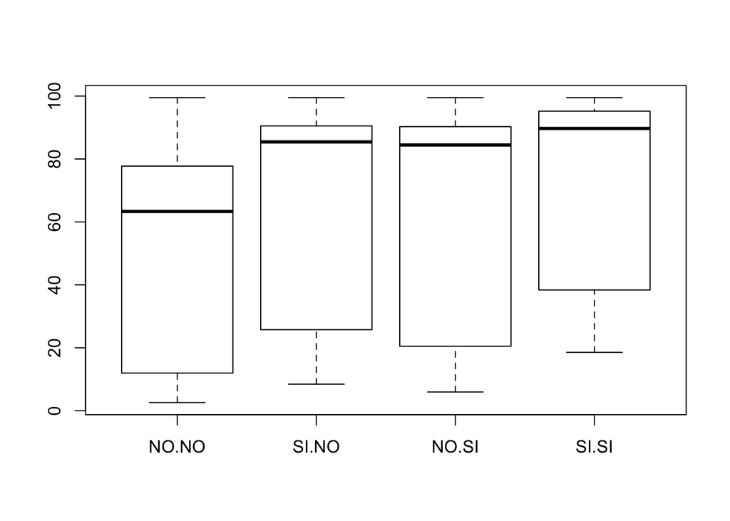

```r
boxplot(cbind(SALUD, EDUCACION,ELECTRIFICACION) ~ CAPITAL + COSTA,
          data=myData)
```

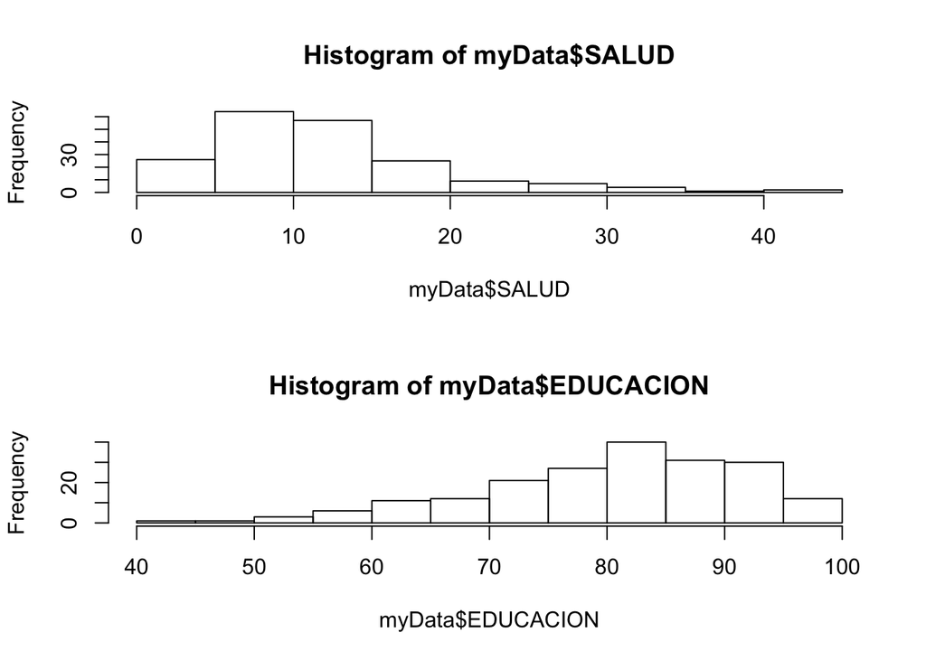

```r
par(mfrow=c(2,1))
hist(myData$SALUD)
hist(myData$EDUCACION)
```

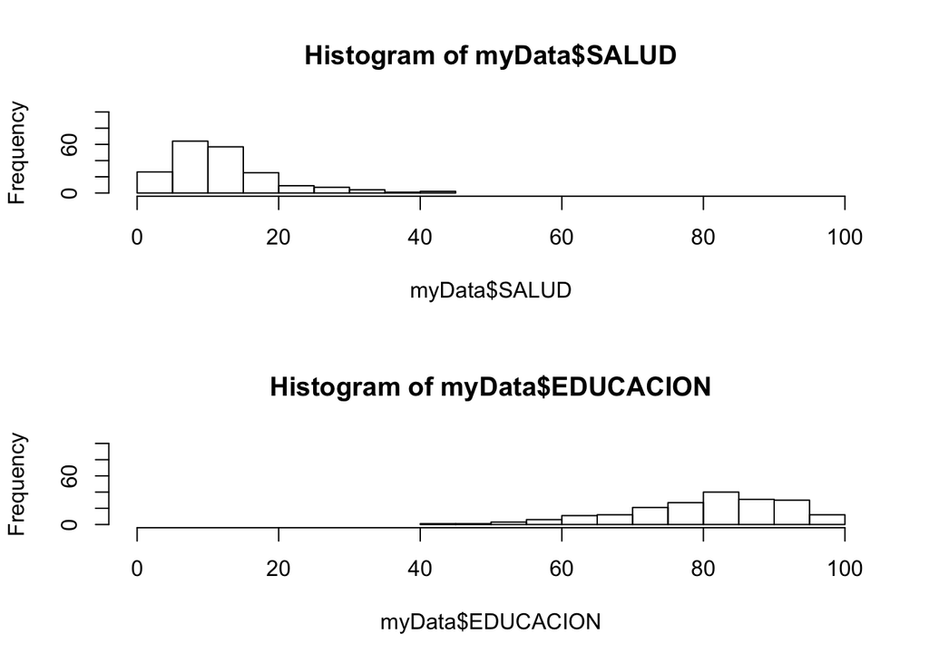

```r
par(mfrow=c(2,1))
hist(myData$SALUD,xlim = c(0,100),ylim=c(0,100))
hist(myData$EDUCACION,xlim = c(0,100),ylim=c(0,100))
```

Inicio

## Numérico - Numérico

Un básico análisis corresponde al concepto de correlación:

```r
res <- cor(myData[,c(6:10)],use='complete.obs')
round(res, 2)
```

```
##                 IDENTIDAD SALUD EDUCACION SANEAMIENTO ELECTRIFICACION
## IDENTIDAD            1.00  0.32      0.62        0.42            0.46
## SALUD                0.32  1.00      0.38        0.63            0.53
## EDUCACION            0.62  0.38      1.00        0.42            0.68
## SANEAMIENTO          0.42  0.63      0.42        1.00            0.65
## ELECTRIFICACION      0.46  0.53      0.68        0.65            1.00
```

De hecho, tenemos una versión no-paramétrica para Pearson:

```r
res2=cor(myData[,c(6:10)],use='complete.obs',method='spearman')
round(res2, 2)
```

```
##                 IDENTIDAD SALUD EDUCACION SANEAMIENTO ELECTRIFICACION
## IDENTIDAD            1.00  0.37      0.58        0.40            0.53
## SALUD                0.37  1.00      0.39        0.61            0.52
## EDUCACION            0.58  0.39      1.00        0.39            0.67
## SANEAMIENTO          0.40  0.61      0.39        1.00            0.67
## ELECTRIFICACION      0.53  0.52      0.67        0.67            1.00
```

Veamos una gráfica:

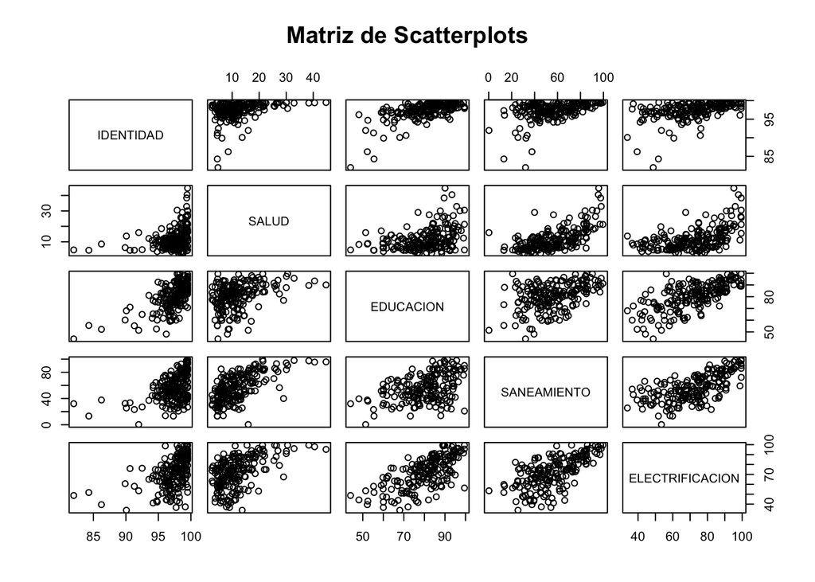

```r
plot(myData[,c(6:10)], main="Matriz de Scatterplots")
```

Inicio

#### [VOLVER AL SILABO](https://inteligenciaperu.github.io/Estadistica/)